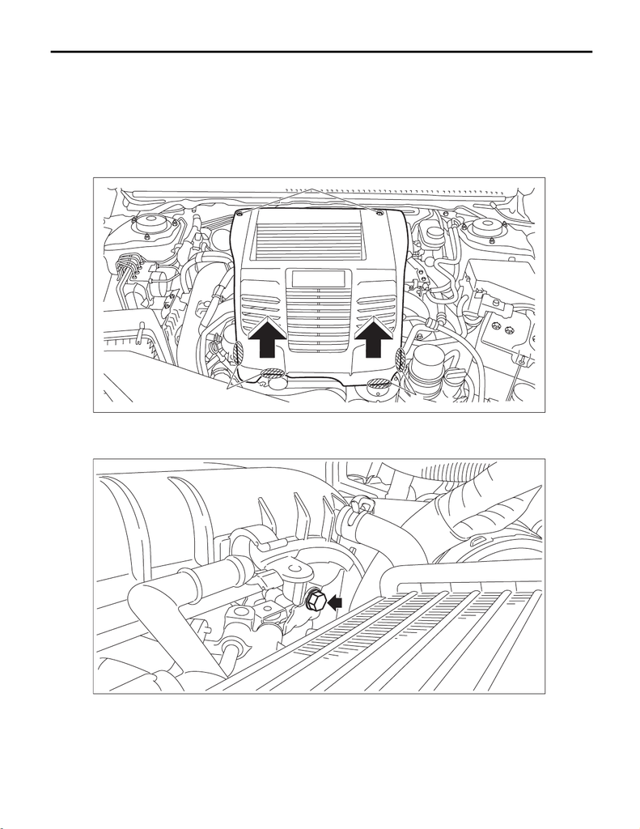

EC(w/o STI)-22

Purge Control Solenoid Valve

EMISSION CONTROL (AUX. EMISSION CONTROL DEVICES)

5. Purge Control Solenoid Valve

A: REMOVAL

1. PURGE CONTROL SOLENOID VALVE 1

1) Remove the collector cover.

(1) Remove the clips (A).

(2) Hold the shaded area (B) by hand and carefully pull the RH side (C) upward.

(3) Hold the shaded area (D) by hand and carefully pull the LH side (E) upward.

2) Disconnect the ground terminal from battery sensor. <Ref. to NT-5, BATTERY, NOTE, Note.>

3) Remove the brake vacuum pump. <Ref. to BR-81, REMOVAL, Brake Vacuum Pump.>

4) Remove the bolt which secures the solenoid valve bracket from the intake manifold.

EX-03204

(A)

(B)

(C)

(E)

(D)

EC-03278

15WRX_STI_US_EN.book 22 ページ ２０１５年２月１３日 金曜日 午前１１時２０分

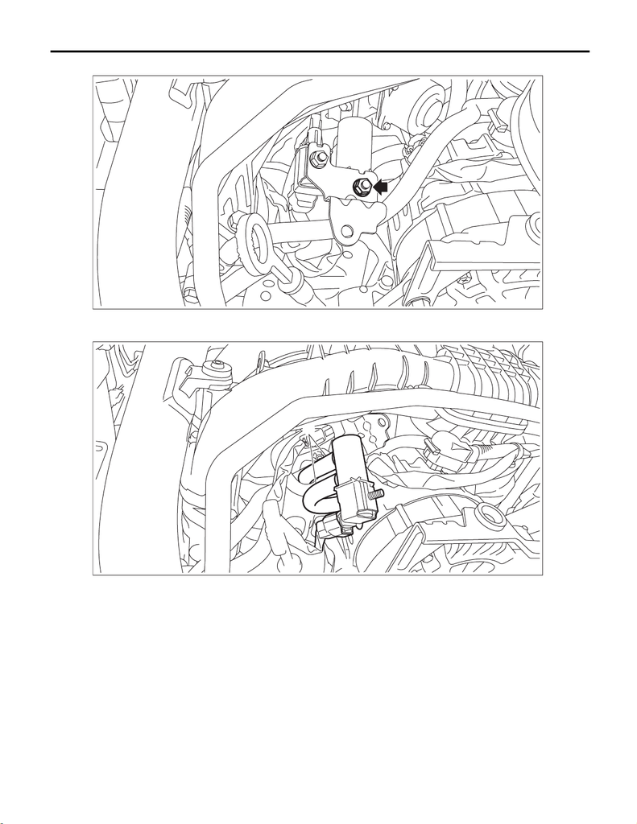

EC(w/o STI)-23

Purge Control Solenoid Valve

EMISSION CONTROL (AUX. EMISSION CONTROL DEVICES)

5) Remove the nut which secures the purge control solenoid valve 1 to the solenoid valve bracket.

6) Disconnect the connector (A) and vacuum hose (B) from the purge control solenoid valve 1, and remove

the purge control solenoid valve 1.

EC-03125

EC-03126

(B)

(A)

15WRX_STI_US_EN.book 23 ページ ２０１５年２月１３日 金曜日 午前１１時２０分

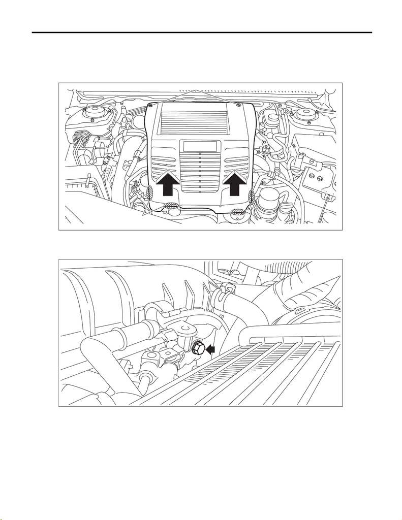

EC(w/o STI)-24

Purge Control Solenoid Valve

EMISSION CONTROL (AUX. EMISSION CONTROL DEVICES)

2. PURGE CONTROL SOLENOID VALVE 2

1) Remove the collector cover.

(1) Remove the clips (A).

(2) Hold the shaded area (B) by hand and carefully pull the RH side (C) upward.

(3) Hold the shaded area (D) by hand and carefully pull the LH side (E) upward.

2) Disconnect the ground terminal from battery sensor. <Ref. to NT-5, BATTERY, NOTE, Note.>

3) Remove the brake vacuum pump. <Ref. to BR-81, REMOVAL, Brake Vacuum Pump.>

4) Remove the bolt which secures the solenoid valve bracket from the intake manifold.

EX-03204

(A)

(B)

(C)

(E)

(D)

EC-03278

15WRX_STI_US_EN.book 24 ページ ２０１５年２月１３日 金曜日 午前１１時２０分

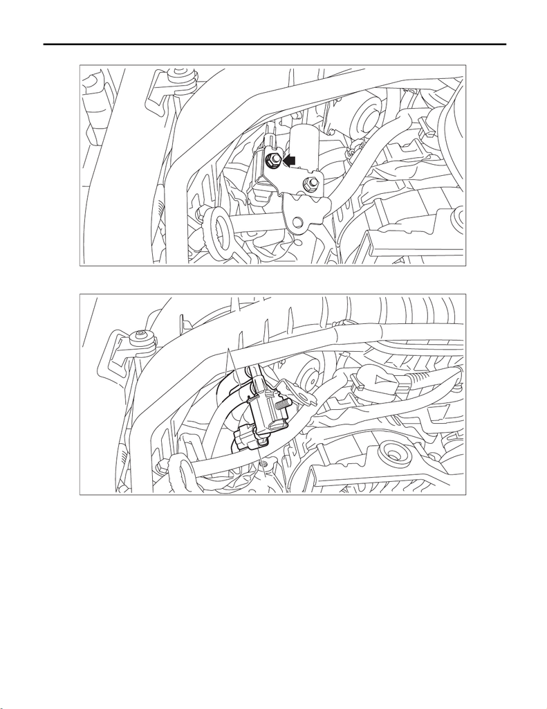

EC(w/o STI)-25

Purge Control Solenoid Valve

EMISSION CONTROL (AUX. EMISSION CONTROL DEVICES)

5) Remove the nut which secures the purge control solenoid valve 2 to the solenoid valve bracket.

6) Disconnect the connector (A) and vacuum hose (B) from the purge control solenoid valve 2, and remove

the purge control solenoid valve 2.

EC-03127

EC-03128

(B)

(A)

15WRX_STI_US_EN.book 25 ページ ２０１５年２月１３日 金曜日 午前１１時２０分

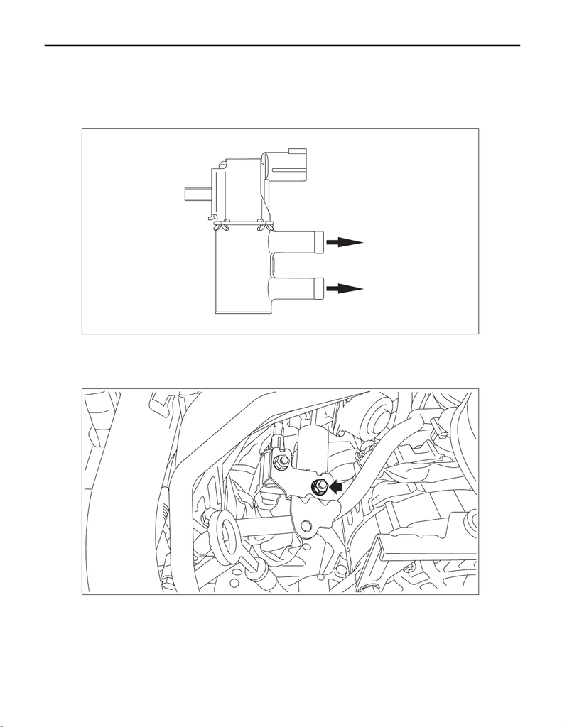

EC(w/o STI)-26

Purge Control Solenoid Valve

EMISSION CONTROL (AUX. EMISSION CONTROL DEVICES)

B: INSTALLATION

1. PURGE CONTROL SOLENOID VALVE 1

Install in the reverse order of removal.

NOTE:

Connect the vacuum hose as shown in the figure.

Tightening torque:

6.4 N·m (0.7 kgf-m, 4.7 ft-lb)

(a) To intake manifold (b) To fuel pipe

EC-03129

(a)

(b)

EC-03125

15WRX_STI_US_EN.book 26 ページ ２０１５年２月１３日 金曜日 午前１１時２０分

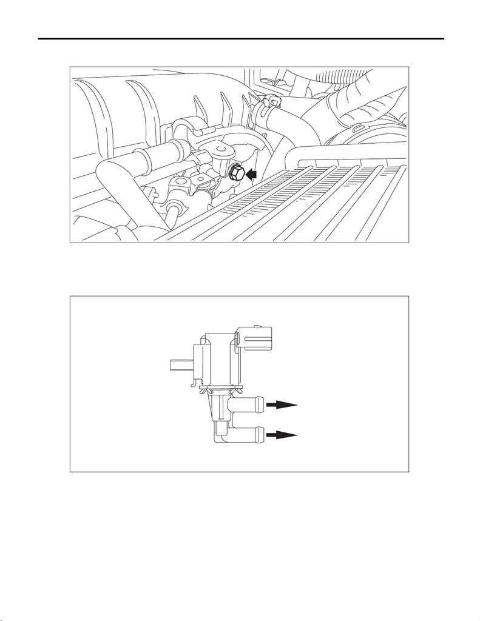

EC(w/o STI)-27

Purge Control Solenoid Valve

EMISSION CONTROL (AUX. EMISSION CONTROL DEVICES)

Tightening torque:

19 N·m (1.9 kgf-m, 14.0 ft-lb)

2. PURGE CONTROL SOLENOID VALVE 2

Install in the reverse order of removal.

NOTE:

Connect the vacuum hose as shown in the figure.

(a) To intake duct (b) To fuel pipe

EC-03278

EC-03130

(a)

(b)

15WRX_STI_US_EN.book 27 ページ ２０１５年２月１３日 金曜日 午前１１時２０分

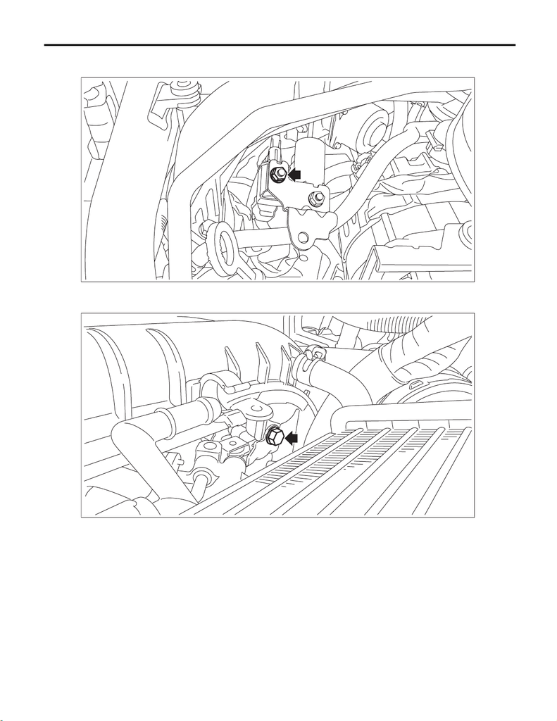

EC(w/o STI)-28

Purge Control Solenoid Valve

EMISSION CONTROL (AUX. EMISSION CONTROL DEVICES)

Tightening torque:

6.4 N·m (0.7 kgf-m, 4.7 ft-lb)

Tightening torque:

19 N·m (1.9 kgf-m, 14.0 ft-lb)

EC-03127

EC-03278

15WRX_STI_US_EN.book 28 ページ ２０１５年２月１３日 金曜日 午前１１時２０分

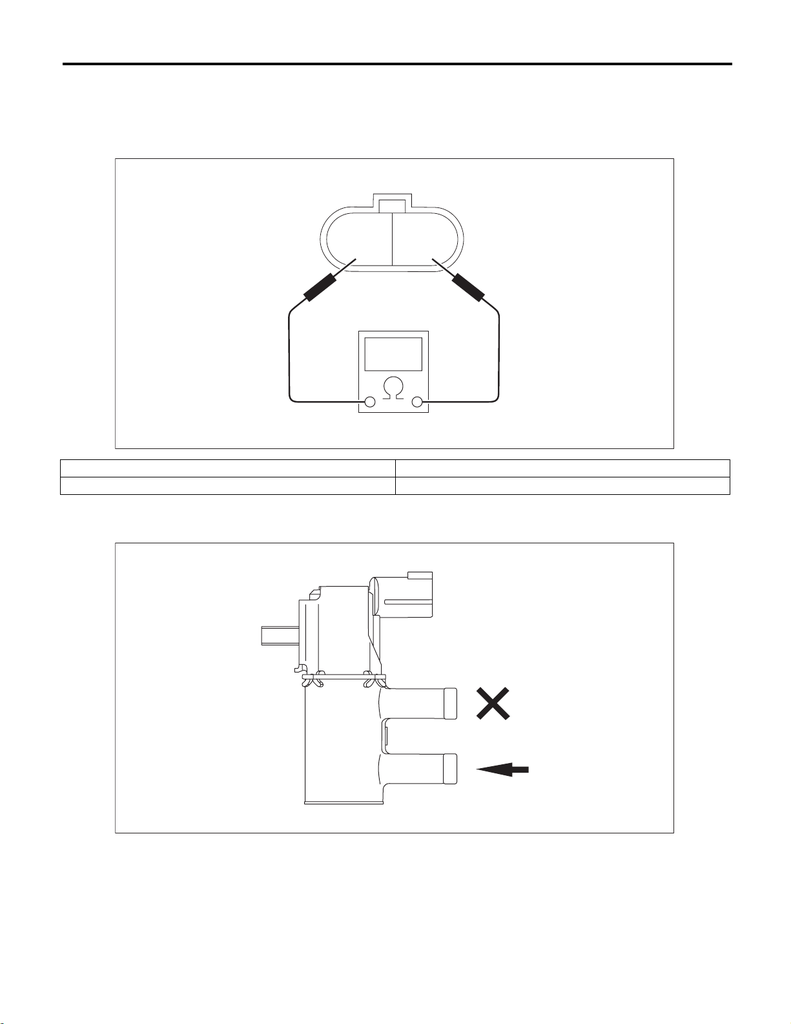

EC(w/o STI)-29

Purge Control Solenoid Valve

EMISSION CONTROL (AUX. EMISSION CONTROL DEVICES)

C: INSPECTION

1. PURGE CONTROL SOLENOID VALVE

1) Check that the purge control solenoid valve has no deformation, cracks or other damages.

2) Measure the resistance between the purge control solenoid valve terminals.

3) Check that air does not come out from (B) when air is blown into (A).

• Purge control solenoid valve 1

Terminal No. Standard

1 and 2 24±3 Ω (20°C (68°F))

EC-02799

21

EC-03131

(B)

(A)

15WRX_STI_US_EN.book 29 ページ ２０１５年２月１３日 金曜日 午前１１時２０分

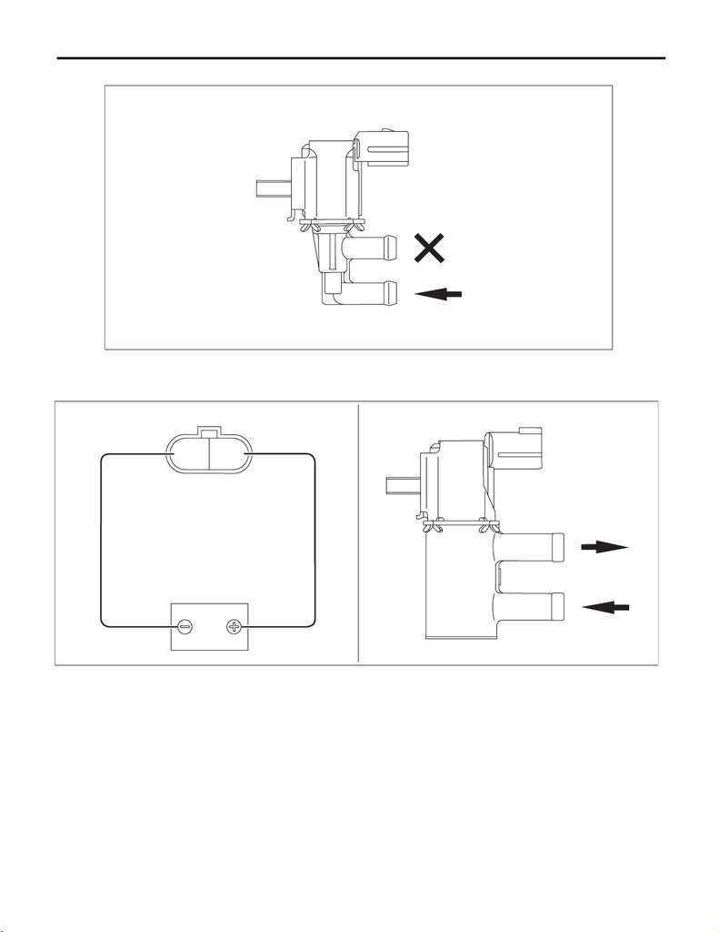

EC(w/o STI)-30

Purge Control Solenoid Valve

EMISSION CONTROL (AUX. EMISSION CONTROL DEVICES)

• Purge control solenoid valve 2

4) Connect the battery positive terminal to the terminal No. 1 and the battery negative terminal to the terminal

No. 2. Check that air is discharged from (B), when supplying air to (A).

• Purge control solenoid valve 1

EC-03132

(B)

(A)

EC-03133

21

(B)

(A)

15WRX_STI_US_EN.book 30 ページ ２０１５年２月１３日 金曜日 午前１１時２０分

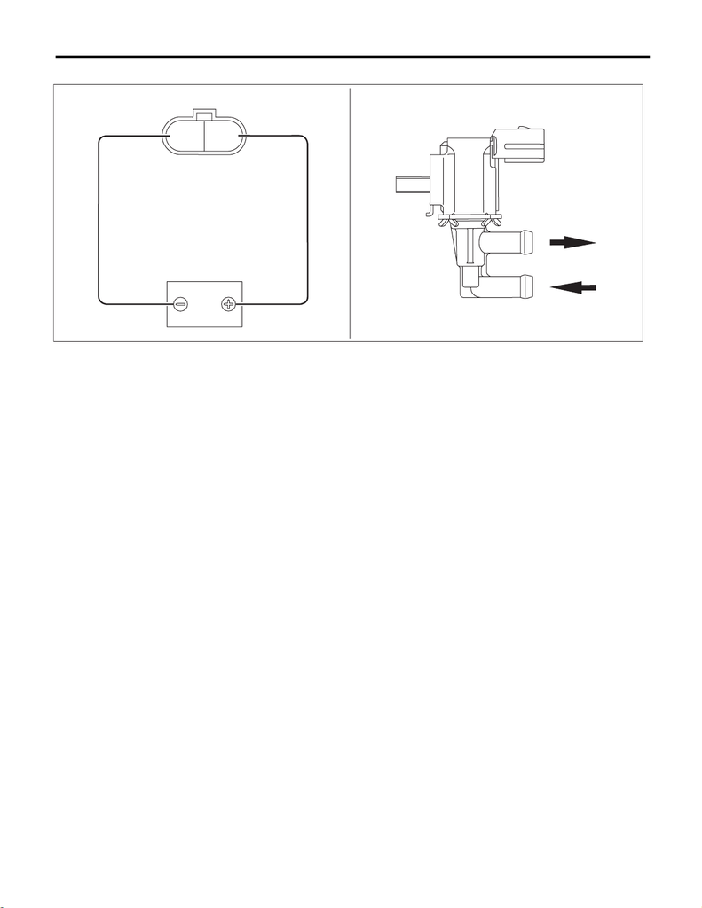

EC(w/o STI)-31

Purge Control Solenoid Valve

EMISSION CONTROL (AUX. EMISSION CONTROL DEVICES)

• Purge control solenoid valve 2

2. OTHER INSPECTIONS

Check the vacuum hose for cracks, damage or looseness.

EC-03134

21

(A)

(B)

15WRX_STI_US_EN.book 31 ページ ２０１５年２月１３日 金曜日 午前１１時２０分